# Stock Analysis with PerformanceAnalytics

jy

2023-05-07

## Intro

Examples of return and portfolio analysis that can be done with the PerformanceAnalytics package. A basic starting point, **far from comprehensive**.

- [Performance Analytics pkg manual](https://cran.r-project.org/web/packages/PerformanceAnalytics/PerformanceAnalytics.pdf) - very thorough documentation but the challenge is it is arranged alphabetically by function (as typical of R vignettes). Works best if you already know what you are looking for, rather than a linear learning tool. There is an intro section that provides some lay-of-the-land for returns-based-analysis (RBA).
- [Blog post: Performance Analytics: An Indispensable Quant Tool for Any Investor](https://franklinparker.com/2019/02/16/performanceanalytics-an-indespensible-quant-tool-for-any-investor/) - brief but helpful tips on getting started.

## Get Price Data

Select 3 ETFs to compare for the purpose of selection.

```r
etf_symbols <- c("^GSPC","VTI","VIG","ZLB.TO")
## set empty object
etf_all <- NULL
## loop through each stock, binding cols as you go
for(stocks in etf_symbols){
  etf_all <- cbind(etf_all,
                      getSymbols(Symbols=stocks,
                                 from='2018-01-01', periodicity='daily',
                                 auto.assign = FALSE))
}
## remove any NA rows


head(etf_all)
```

```
##            GSPC.Open GSPC.High GSPC.Low GSPC.Close GSPC.Volume GSPC.Adjusted
## 2018-01-02   2683.73   2695.89  2682.36    2695.81  3397430000       2695.81
## 2018-01-03   2697.85   2714.37  2697.77    2713.06  3544030000       2713.06
## 2018-01-04   2719.31   2729.29  2719.07    2723.99  3697340000       2723.99
## 2018-01-05   2731.33   2743.45  2727.92    2743.15  3239280000       2743.15
## 2018-01-08   2742.67   2748.51  2737.60    2747.71  3246160000       2747.71
## 2018-01-09   2751.15   2759.14  2747.86    2751.29  3467460000       2751.29
##            VTI.Open VTI.High VTI.Low VTI.Close VTI.Volume VTI.Adjusted VIG.Open
## 2018-01-02   137.75   138.23  137.44    138.22    3699700     126.4617   102.36
## 2018-01-03   138.39   139.10  138.30    139.02    3052300     127.1936   102.55
## 2018-01-04   139.42   139.81  139.35    139.55    2572400     127.6786   103.16
## 2018-01-05   140.02   140.44  139.72    140.37    2188500     128.4288   103.67
## 2018-01-08   140.31   140.77  140.10    140.69    2655300     128.7215   104.03
## 2018-01-09   140.92   141.31  140.71    140.95    2625200     128.9594   104.46
##            VIG.High VIG.Low VIG.Close VIG.Volume VIG.Adjusted ZLB.TO.Open
## 2018-01-02   102.46  102.13    102.39     881200     92.70284       30.61
## 2018-01-03   102.90  102.39    102.86    1218200     93.12841       30.52
## 2018-01-04   103.48  103.15    103.25    1757800     93.48150       30.44
## 2018-01-05   104.05  103.55    104.02     750900     94.17864       30.40
## 2018-01-08   104.37  103.77    104.32     829600     94.45027       30.38
## 2018-01-09   104.92  104.40    104.66     754700     94.75809       30.37
##            ZLB.TO.High ZLB.TO.Low ZLB.TO.Close ZLB.TO.Volume ZLB.TO.Adjusted
## 2018-01-02       30.61      30.45        30.50         31400        26.70549
## 2018-01-03       30.55      30.44        30.44         57100        26.65296
## 2018-01-04       30.50      30.40        30.40         57300        26.61793
## 2018-01-05       30.40      30.30        30.33         53800        26.55664
## 2018-01-08       30.38      30.25        30.31         70600        26.53913
## 2018-01-09       30.37      30.26        30.29         63100        26.52162
```

### Initial viz

- Prices: not that useful because scale comes into play, and is irrelevant

```r
dygraph(Ad(etf_all))
```

[interactive chart not shown]

## Normalized price ranges for comparison

To enable better comparison of prices, we can normalize them with min-max-normalization to set them all between 0 and 1.

From chatGPT: “Normalizing between 0 and 1 (also called min-max normalization) scales the variables to have a minimum value of 0 and a maximum value of 1. This method is useful when you want to preserve the original range of the data and the relationship between the values.”

```r
## first remove any NA values - they will mess up calculations
etf_all <- na.omit(etf_all)
## use apply to calc min-max normalization
etf_all_mmn <- xts(apply(etf_all, 2, function(x) (x-min(x))/(max(x)-min(x))),
                   order.by=index(etf_all))
```

```r
dygraph(Ad(etf_all_mmn))
```

[interactive chart not shown]

More useful view where we can see the tight connection in prices - and instances where the connection is not so tight.

Still, to get to the heart of the matter, we need to look at **returns**.

## Get Returns

’cause in the end: **returns are what matter** ;)

**Performance Analytics pkg** focuses on returns analysis. From the manual:

*“Performance measurement starts with returns… Most of the recent work in performance analysis is focused on returns rather than prices and sometimes called”returns-based analysis” or RBA. This “price per unit of investment” standardization is important for two reasons - first, it helps the decision maker to compare opportunities, and second, it has some useful statistical qualities.”*

### Convert price data to returns

Using monthly returns in this case.

```r
## potentially simpler way to calc monthly returns
## calc only on adjusted prices - every 6th col
etf_mth_ret <- NULL
for(i in 1:length(etf_symbols)){
  cadj <- i*6
  etf_mr <- monthlyReturn(etf_all[,cadj])
  colnames(etf_mr) <- etf_symbols[i]
  etf_mth_ret <- cbind(etf_mth_ret, etf_mr)
}
```

## Correlations

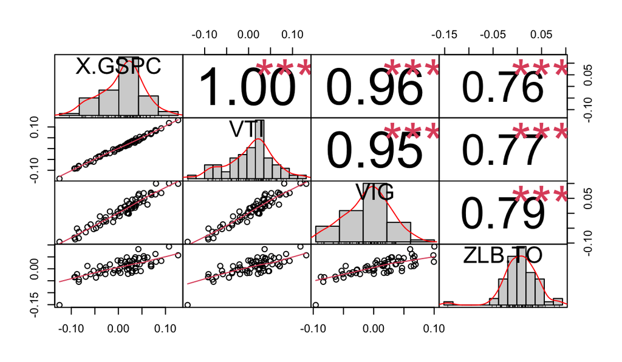

```r
chart.Correlation(etf_mth_ret)
```

From [Performance Analytics: An Indispensable Quant Tool for Any Investor](https://franklinparker.com/2019/02/16/performanceanalytics-an-indespensible-quant-tool-for-any-investor/)

“The diagonal gives you the return distribution of each ETF. I like to see how the returns are distributed—are they concentrated in the center? are there lots of outliers? are they heavily skewed? is something just weird? Indeed, this plot recently helped me immediately throw out a position under consideration because the distribution was barbelled (but more heavy left-tailed).”

## Distribution of Returns

Focus on individual distribution of returns:

- line is normal curve
- shows 95% value at risk level (incl. modified)

```r
## function for producing individual dist
## - provide symbol to select (by number in list), list of symbols (from start), dataset of returns as data frame
fn_ind_rtn_dist <- function(sel, symbs, data){
  chart.Histogram(data[,sel],
                methods=c("add.normal","add.risk"),
                colorset = c('steelblue','','navyblue'),
                main=symbs[sel])
}
```

```r
nsymb <- length(etf_symbols)
mfr <- ifelse(nsymb<4,1,round(nsymb/2))
mfc <- min(nsymb,3)
par(mfrow=c(mfr,mfc))
for(c in 1:length(etf_symbols)){
 fn_ind_rtn_dist(c, etf_symbols, etf_mth_ret)
}
```

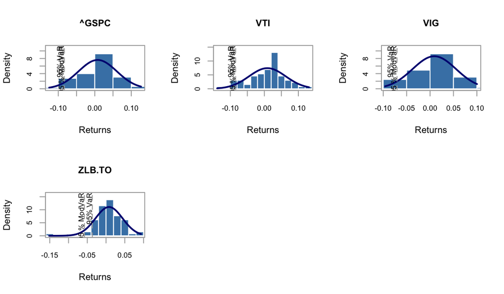

## Drawdown comparisons

Shows how resilient investment is during negative return situations.

- downward movement relative to a high.

```r
#sel <- 1
#chart.Drawdown(etf_mth_ret_cl[,sel], geometric=TRUE, colorset="firebrick4", main=etf_symbols[sel])
## plot.engine options: ggplot2, plotly, dygraph, googlevis, default
chart.Drawdown(etf_mth_ret, geometric=TRUE, legend.loc='bottomleft', plot.engine="dygraph")
```

[interactive chart not shown]

## Upside/Downside Capture

Shows the relative percentage of upside and downside captured by an asset relative to a benchmark.

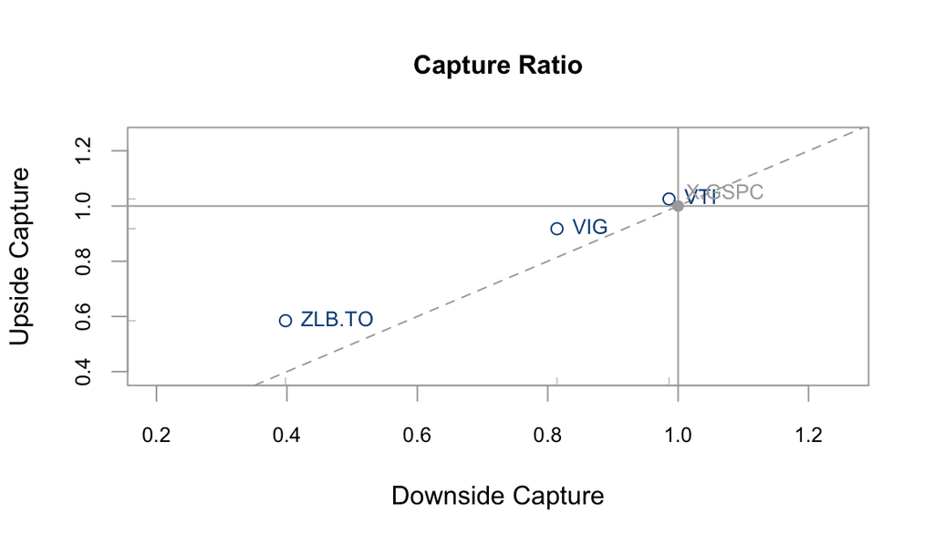

```r
chart.CaptureRatios(Ra=etf_mth_ret[,2:4], Rb=etf_mth_ret[,"X.GSPC"], colorset="dodgerblue4",
    main="Capture Ratio")
```

Couple things to note:

- the benchmark will be situated where the x and y axes cross at 1. This is because it captures 100% of the upside and downside of itself.
- other assets are then evaluated by how far and what direction they sit on both x and y axis from the benchmark.
- downside that is lower than 1 means the asset tends to not to react with as much losses on the downside as the benchmark.
- upside greater than 1 means the asset tends to see greater gains on the upside than the benchmark.

## Conclusion

Lots to work with in the PerformanceAnalytics package - these examples are not even scratching the surface. Likely have further editions to come.